# TP Biochimie BAB2 Q1

Guillaume Gégo

Raphaël Deroux

Emeline Derycke

05/11/2020

## **Atelier 3:** Les sucres

### Introduction

#### Qu’est-ce qu’un sucre?

Les glucides (carbohydrates, sucres, -oses, hydrates de carbone), sont une classe de macromolécules dont la formule chimique correspond à ce modèle: Cn(H2O)p. Constituants essentiels à la survie des êtres vivants, ils accomplissent des fonctions allant de la structuration cellulaire à la mise en réserve. Ce sont des constituants essentiels des êtres vivants et de leur mode de nutrition. Cependant, ils ne remplissent jamais un rôle informationnel. Les monomères constituant l’unité de base des glucides sont les monosaccharides.

#### Les monosaccharides

Les sucres sont donc des poly-alcools dont les unités fonctionnelles sont les groupements carbonyles et hydroxyles. Si le carbonyle est terminale, on parlera d’**aldoses**. Si par contre il est intégré à l’intérieur de la chaîne carbonée, on parlera de **cétones**.

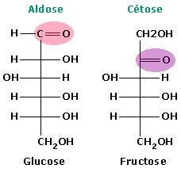

Figure: Différence Aldose - Cétose

#### Formation d’hémiacétal (Formes cycliques des pentoses-hexoses)

En solution aqueuse, les monosaccharides possédant au moins 5 atomes de carbone forment des structures cycliques dans lesquelles le groupement carbonyle forme une liaison covalente avec l’oxygène d’un groupement hydroxyle. Il y a alors formation d’un hémiacétal. Les hémiacétals peuvent être sous forme furanique (5C. ex: ribose) et pyranique (6C. ex: glucose, fructose).

#### Les disaccharides

L’interaction entre deux monosaccharides est réalisable au moyen d’un lien *osidique* (éther). Si un glucose se lie avec un fructose, on obtient du saccharose. L’amidon quant à lui est formé d’amylose (25%) et d’amylopectine (75%), tout deux polymères de glucose.

#### Furfural

**A pH < 7 (acide):** Les pentoses se déshydratent et deviennent des résidus furfural (si 6C: furfural avec hydroxyméthyl en C5).

#### Isomérisation de De Bryun - Von Ekenstein

Cétose <—> Aldose à pH 7.

Aussi, les disaccharides (maltose, saccharose) et les polysaccharides (glycogène, amidon) sont hydrolysés en milieu acide. Les monosaccharides (fructose, glucose) ainsi libérés sont ensuite transformés en furfural (voir point ci dessus).

#### Les polysaccharides

Constitués de longues chaînes récurrentes ou non de monomères, ils remplissent des fonctions de réserve (amidon) ou de structure (cellulose).

#### Fonctionnement du test de Fehling

Le test de Fehling est une méthode qui permet de révéler la présence de glucides. La liqueur de Fehling réagit avec les fonctions aldehydes dans une réaction d’oxydo-réduction, en jouant le rôle de l’oxydant.

Lors de la réaction, l’ion Cu<sup>2+</sup> oxyde la fonction aldéhyde (La fonction cétone, elle ne réagit pas car son étage d’oxydation est bien supérieur). L’aldéhyde, quant à lui, réduit l’ion et entraine par la même sa précipitation. C’est cette précipitation qui déterminera si le test est positif ou non. De fait, le Cu<sub>2</sub>O possède une couleur rouge très identifiable.

Réaction: R-CHO + 2Cu(OH)<sub>2</sub> → RCOOH + Cu<sub>2</sub>O(s) + 2H<sub>2</sub>O

La présence des des ions tartrates est également très importante car elle empêche la formation d’hydroxyde cuivrique. Concrètement, cela signifie que le cuivre restera sous forme d’un complexe d’une couleur bleue soluble alors que l’hydroxyde cuivrique, lui, est d’une couleur bleue insoluble. Par après, et à température ambiante, il y aurait naturellement formation d’oxyde de cuivre(II), complexe de couleur noir insoluble.

#### Fonctionnement du test de Tollens

Le test de Tollens est une méthode qui permet de révéler la présence de glucides. Le réactif de Tollens réagit avec des fonctions aldéhydes dans une réaction d’oxydo-réduction, en jouant le rôle de l’oxydant.

Le réactif est une solution comprenant du nitrate d’argent. C’est cet Ag<sup>2+</sup> qui oxyde la fonction aldéhyde (La fonction cétone, elle ne réagit pas car son étage d’oxydation est bien supérieur). L’aldéhyde, quant à lui, réduit l’ion et entraine par la même sa précipitation.

Réaction: R-CHO + 2Ag(NH<sub>3</sub>)<sub>2</sub>OH + NaOH → RCOONa + 2Ag + 2H<sub>2</sub>O + 4NH<sub>3</sub>

Il se forme alors un dépot d’argent sur les parois en donnant ainsi un effet miroir.

### But

L’objectif de cet atelier est de mettre en évidence les caractéristiques de différents carbohydrates. Une différence moléculaire pourra être démontrée grâce aux tests de Fehling et de Tollens entre les aldoses et les cétoses. L’autre point d’intêret sera de démontrer et comprendre la digestion de glucose par les levures ainsi que le rendement de cette fermentation.

### Matériel

- Liqueur de Fehling
- Réactif de Tollens
- Solutions de fructose(5%), glucose(5%), amidon(5%), surcose(5%)
- Suspension de levure

### Méthodes

#### Préparation des levures

Il faut peser 4g de levures mises à dispositions. On les mets dans un tube à centrifuger et on les suspends dans 40ml d’eau. On les fait centrifuger 5 minutes pour ensuite séparer le culot du surnageant. On réitère la supsension et la centrifugation une seconde fois. Encore une fois, on se débarrasse du surnageant et on reprend le culot dans 5ml d’eau distillée.

#### Mise en évidence des carbohydrates.

##### **Test de Fehling**

L’expérience consite à ajouter 1ml des soltuions de glucose(5%), fructose(5%), amidon(5%), sucrose (5%) et sucrose(5%) acidifié dans des 5 tubes à essais différents. Dans chancun de ces tubes à essais, auront été mis au préalable 1ml de la solution A et 1ml de la solution B. Afin de catalyser la réaction, les tubes sont placés dans un bain-marie à 100°C durant 5 minutes.

##### **Test de Tollens**

On répartit, dans 4 tubes à essais, 1ml du réactif de Tollens. On verse ensuite dans les tubes 1ml des solutions de fruvtose(5%), glucose(5%), amidon(5%) et sucrose(5%). La solution de sucrose(5%) acidifiée ne sera pas utilisée.

#### Digestion du glucose par les levures

Pour cette partie-ci, il a fallut utiliser 3 fioles coniques avec un compratiment central.Dans chaque fiole, nous avons ajouté 0.6ml de la solution de NaOH(3M) dans le compartiment central et 1.5ml de la suspension de levure dans le compartiment extérieur.Nous avons également versés, de manières séparée, dans le compartiment extérieur des 3 fioles les solutions suivantes:

- 2.5ml d’H<sub>2</sub>O -> Fiole n°1
- 2.5ml de ma solution de glucose (20mg/ml) -> Fiole n°2
- 2.5ml de ma solution de glucose (40mg/ml) -> Fiole n°3

Chaque fiole a ensuite été fermée avec 2 feuilles de parafilm pour hermétiser le système.Les fioles sont ensuite incubées durant 45 minutes à 25°C. Au terme de ces 45 minutes, on interrompt le processus de fermentation en injectant à travers le parafilm 1ml de TCA 20% dans le compartiment extérieur de chaque fiole. On titrera en suite le le CO2 produit par la fementation. On va donc ajouter dans des béchers séparés 2ml de BaCl<sub>2</sub> 1M, 1ml H<sub>2</sub>O, 3 gouttes de phénophtaléine, et 0.5ml du NaOH de chaque fiole. Le titrant est de l’acide chlorhydrique 0.3M. Un titrage test est bien évidemment effectué au préalable avec 0.5ml de NaOH 3M frais.

### Résultats

#### Résultats de la mise en évidence des carbohydrates

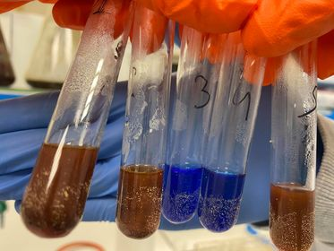

Test de Fehling

Dans l’ordre: fructose, glucose, amidon, sucrose et sucrose acidifié. On constate facilement que seuls le fructose, le glucose et le sucrose acidifié ont réagi.

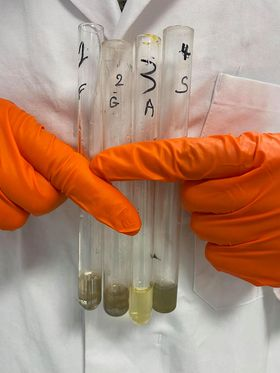

#### Résultats du titrage

Les résultats des titrages sont les suivants:

- Fiole 1: 5.7ml
- Fiole 2: 3.5ml
- Fiole 3: 1.6ml

### Discussion

#### Mise en évidence de carbohydrates

##### Calcul du rendement

Les équations de réactions simplifiées:

- C<sub>6</sub>H<sub>12</sub>O<sub>6</sub> –> pyruvate + 2CO<sub>2</sub>
- CO<sub>2</sub> +2NaOH –< Na<sub>2</sub>CO<sub>3</sub> + H<sub>2</sub>O
- HCl + NaOH –> NaCl + H<sub>2</sub>O

**Fiole 1:** On ne peut calculer aucun rendement pour cette fiole car elle ne contient simplement pas de glucose.

**Fiole 2:** On a rajouté 3.5ml de HCl ce qui correspond à 0.00105 moles de NaOH. On peut donc calculer la quantitée de NaOH utilisée en soustrayant celle restante à celle d’origine:

- 0.00171 - 0.00105 = 0.00066 moles de NaOH utilisées

Or il y à un rapport 4 entre la quantité de NaOH utilisée et la quantité de gulcose utilisée:

- 0.00066/4 = 0.000165 moles de glucose utilisées

Le rendement final est donné par le rapport entre la quantité de glucose utilisée et la quantitée de glucose initiale:

- Rendement: (0.000165/0.000278) x 100 = **59.35%**

**Fiole 3:** Le raisonnement est identique à celui de la fiole n°2. La seule variable qui change est la concentration de la solution de glucose utilisée.

- Quantité de NaOH utilisée: 0.00171 - 0.00048 = 0.00123 moles
- Quantité de glucose utilisée: 0.00123 / 4 = 0.0003075 moles
- Rendement: (0.0003075 / 0.000555) x 100 = **55.40%**

### Conclusion

#### Mise en évidence des carbohydrates

Durant les test de Fehling et de Tolens nous avons pu mettre évidence les carbohydrates avec succès. Cependant, il est à remarquer que ces tests ne sont efficaces que sur les monosaccharides.

Nous avons démontrer avec succès la consommation de glucose par les levures en milieu anaérobie ainsi que calculer le rendement de cette fermentation en fonction de la quantitée de glucose.